# Air Sciencia

Evaluating Airline Preformance

Author

Sasha Green, Arman Naseh, Jake Anszelowicz, Amine Louri

Published

December 8, 2024

## Introduction

On time performance is essential as delays can significantly impact schedules and travel plans, Safety is always non negotiable since it is critical for passenger trust and airline reputation, Airline complaints occur frequently, as their reviews shape an airline’s reputation when customers consider traveling through that airline, and Customer Satisfaction is what reflects the quality of service that passengers can expect. This project will delve deep at some of the key aspects of these factors to provide an exploratory analysis of airline reliability, and our aim is to examine how these elements are measured and whether current methodologies accurately reflect and account for uncontrollable factors like delays and cancellations, which have become a commonplace within the airline industry. We will analyze these trends as the project aims to gain a clearer understanding of these trends in the airline industry’s challenges along with how these aspects influence company ratings, offering insights into what truly shapes reliability from both operational and passenger perspectives.

## Research Question: So How are we going to help?

Our aim is to discover which airline we would recommend to be the safest, least delay ridden yet with the highest satisfaction

## Methodology

### Data Selection

For our Safety data we used data from the aviation safety network which can be viewed here: https://asn.flightsafety.org/database/countries/N/

The aviation safety network is part of the Flight Safety Foundation which gives up to date information on airplane accidents and incidents. Our data was derived from their Accident Database which is updated daily and information spanning from 1919. They get the information on these incidents from official governmental agencies, such as air accident investigation boards and civil aviation authorities. This is a very valid source as there is no reason for it to be biased towards any airline or company as it’s just compiling reports from government agencies into easily accessible data.

For our customer satisfaction data we used two different data

On time preformance

Airline_Delay_Cause.csv

BTS | OT Delay

This data comes from the Bureau of Transportation Statistics(BTS). This should be considered reliable source data as it is a branch of the Department of Transportation, which is a government agency, and its whole purpose is to produce data about aviation as well as other modes of transportation that can be viewed and used by people.

June 2023 Consumer Submission Data.pdf

This data also comes from a branch of the Department of Transportation(DOT), the U.S. Department of Transportation’s Office of Aviation Consumer Protection. This agency is committed to making sure customers are safe and protected while flying. This makes them the most reliable possible source when it comes to complaints from these customers as any complaints about any airlines will be handled by them to ensure passengers are being treated well and fairly.

The USA’s Top 10 Domestic Airlines By Daily Flights

This was created by simple flying which I have not heard of before, but is a website that posts about aviation news. The fact that it isn’t a well known publication made it worrisome about its data, but cross referencing with other websites it seems they all have roughly the same numbers and it cites its data from OAG, which is used heavily by companies in the aviation industry. Simple Flying compiled the data into a data table that I could web scrape which is why it was chosen over others for our uses.

## Results

### How do the airline compare in Safety

Most people will agree that safety is and should be the number one concern for airlines. Afterall, they operate ginormous machinery with hundreds of peoples lives at risks for each one of the millions of operations they do every year. We dove right in to analyze this:

### Visualization 1

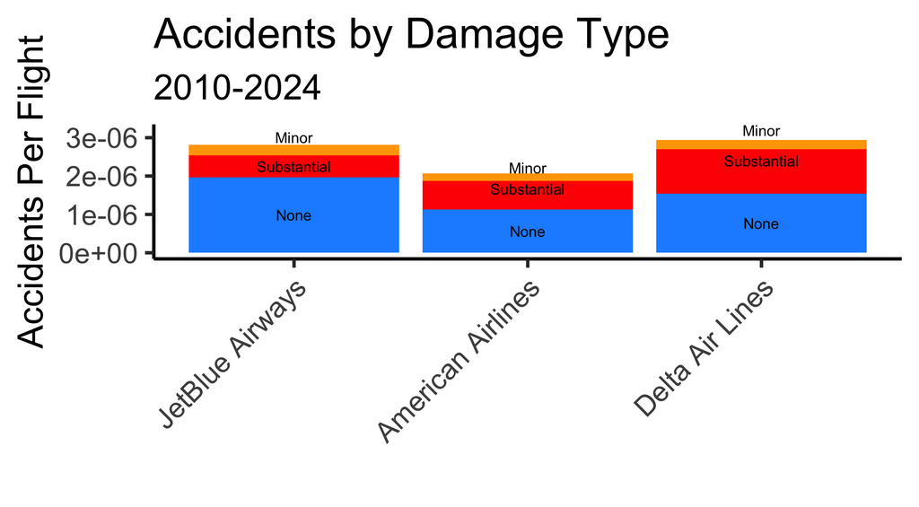

```r
base_url <- "https://asn.flightsafety.org/database/countries/N/"
all_data <- NULL
airlines_to_keep <- c("Delta Air Lines", "American Airlines", "Jetblue Airways")

for (i in 1:10)
{
  url <- paste0(base_url, i)
  page <- read_html(url)
  table_data <- page %>%
    html_nodes("table") %>%
    html_table(fill = TRUE)
  table_data <- table_data[[1]]
  colnames(table_data) <- make.names(colnames(table_data), unique = TRUE)
  table_data <- table_data %>% mutate(across(everything(), as.character))
  table_data <- table_data %>%
    filter(
      grepl("Delta Air Lines", operator, ignore.case = TRUE) |
      grepl("American Airlines", operator, ignore.case = TRUE) |
      grepl("Jetblue Airways", operator, ignore.case = TRUE)
    )
  all_data <- bind_rows(all_data, table_data)
}

data <- all_data %>%
    select(-7,-9,-10)
data_counts <- data %>%
  group_by(operator, dmg) %>%
  summarize(count = n(), .groups = "drop")
data_long <- data_counts %>%
  pivot_wider(names_from = dmg, values_from = count, values_fill = 0) %>%
    select(-5)

data <- data_long %>%
  rename(Minor = min,
         None = non,
         Substantial = sub)

data <- data %>%
  group_by(operator = ifelse(operator == "Jetblue Airways", "JetBlue Airways", operator)) %>%# Combine "JetBlue Airways" and "Jetblue Airways"
  summarize(Minor = sum(Minor),
            None = sum(None),
            Substantial = sum(Substantial)) %>%
    mutate(operator = fct_reorder(operator, None)) %>%
     mutate(
    Cumulative_None = None,
    Cumulative_Substantial = None + Substantial,
    Cumulative_Minor = None + Substantial + Minor
  )

url <- "https://simpleflying.com/usa-top-10-domestic-airlines/"
webpage <- read_html(url)

airline_data <- webpage %>%
  html_table(fill = TRUE) %>%
  .[[1]] %>%
    filter(row_number() %in% c(1,2, 7)) %>%
    clean_names() %>%
    mutate(avg_daily_domestic_flights_march = as.numeric(gsub(",","",avg_daily_domestic_flights_march))) %>%
    select(-3,-4,-5,-6)

combined_data_safety <- bind_cols(data, airline_data) %>%
    mutate(flights = (avg_daily_domestic_flights_march)*5110) %>%
    mutate(none_per_flight = Cumulative_None/flights) %>%
    mutate(minor_per_flight = Cumulative_Minor/flights) %>%
    mutate(sub_per_flight = Cumulative_Substantial/flights)

ggplot(combined_data_safety, aes(x = operator)) +
  geom_bar(aes(y = minor_per_flight, fill = "Minor"), stat = "identity") +
  geom_bar(aes(y = sub_per_flight, fill = "Substantial"), stat = "identity") +
  geom_bar(aes(y = none_per_flight, fill = "None"), stat = "identity") +
  geom_text(aes(y = minor_per_flight / 6 + sub_per_flight, label = ifelse(minor_per_flight > 0, "Minor", "")),
            size = 3, color = "black") +
  geom_text(aes(y = sub_per_flight*8/9,
                label = ifelse(sub_per_flight > 0, "Substantial", "")),
            size = 3, color = "black") +
  geom_text(aes(y = none_per_flight / 2 ,
                label = ifelse(none_per_flight > 0, "None", "")),
            size = 3, color = "black") +
  labs(
    title = "Accidents by Damage Type",
    subtitle = "2010-2024",
    x = ' ',
    y = "Accidents Per Flight"
  ) +
  scale_fill_manual(
    values = c("Minor" = "#FFA500", "None" = "#1E90FF", "Substantial" = "#FF0000")
  ) +
  theme(axis.text.x = element_text(angle = 45, hjust = 1)) +
  guides(fill = "none")
```

The chart shows that in general planes are extremely as you have such a small chance to have any kind of accident and an even smaller chance to get into a substantial accident where there are any injuries or fatalities. There is no clear best or worst here as they are all doing very well minimizing the crashes. If a best had to be chosen it would American Airlines as they have slightly less accidents per flight.

### Visualization 2

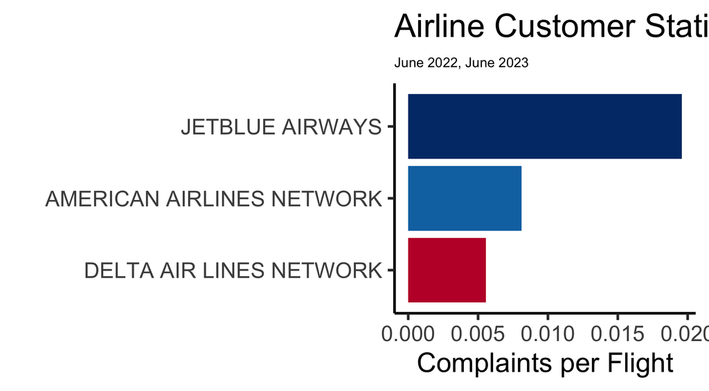

```r
customer <- raw_data_2 %>%
    slice(-1,-12) %>%
    mutate(
        Column2 = as.numeric(Column2) + as.numeric(Column3)
    ) %>%
    select(-Column3) %>%
    mutate(
    Column1 = fct_reorder(Column1, Column2)) %>%
    filter(row_number() %in% c(3, 4, 7)) %>%
    rename(Airline = Column1) %>%
    rename(Complaints = Column2)

combined_data_complaints <- bind_cols(airline_data, customer) %>%
    select(Airline, avg_daily_domestic_flights_march, Complaints) %>%
    mutate(avg_daily_domestic_flights_march = avg_daily_domestic_flights_march*60) %>%
    mutate(complaints_per_flight = Complaints/avg_daily_domestic_flights_march) %>%
    mutate(Airline = fct_reorder(Airline, complaints_per_flight))
ggplot(combined_data_complaints, aes(x = complaints_per_flight, y = Airline, fill = Airline))+
    geom_col()+
    labs(title = "Airline Customer Statisfaction", subtitle = "June 2022, June 2023", x= "Complaints per Flight", y = "") +
     scale_fill_manual(values = c("JETBLUE AIRWAYS" = "#003876", "DELTA AIR LINES NETWORK" = "#C01933", "AMERICAN AIRLINES NETWORK" = "#0D73B1"))+
    theme(
        plot.subtitle = element_text(size = 10)
    ) +
    guides(fill = "none")
```

### Visualization 3

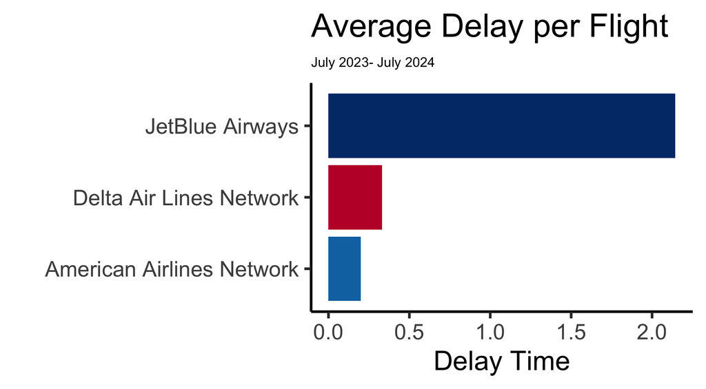

```r
delay <- raw_data_1 %>%
    filter(airport %in% c("JFK", "LAX")) %>%
    select(carrier_name, airport, carrier_delay) %>%
    group_by(carrier_name) %>%
    summarize(carrier_delay = sum(carrier_delay, na.rm = TRUE)) %>%
    mutate(
        carrier_name = fct_reorder(carrier_name, carrier_delay)) %>%
        rename(airline = carrier_name) %>%
        filter(!airline %in% c("Alaska Airlines Network", "Allegiant Air", "Endeavor Air Inc.", "Frontier Airlines","Hawaiian Airlines Network", "Horizon Air","Republic Airline", "SkyWest Airlines Inc.", "Southwest Airlines","Spirit Airlines", "United Air Lines Network"))#only keep delta, jetblue, and american

combined_delay <- bind_cols(delay,airline_data) %>%
    select(-3) %>%
    rename(airline = airline...1) %>%
    mutate(avg_daily_domestic_flights_march = avg_daily_domestic_flights_march*365) %>%
    mutate(delays_per_flight = (carrier_delay/avg_daily_domestic_flights_march))

ggplot(combined_delay, aes(x= delays_per_flight, y= airline, fill = airline)) +
    geom_col() +
    labs(title = "Average Delay per Flight", subtitle = "July 2023- July 2024" , x= "Delay Time", y = "")+
    scale_x_continuous(labels = label_comma()) +
    scale_fill_manual(values = c("JetBlue Airways" = "#003876", "Delta Air Lines Network" = "#C01933", "American Airlines Network" = "#0D73B1"))+
    theme(
        plot.subtitle = element_text(size = 10)
    ) +
    guides(fill = "none")
```

The chart shows the average amount of delay per flight, so obviously the average delay isn’t only a few minutes. This is if you take the total time of all the delays in a year and divided by the total flights in that same period. It is clear from the chart that JetBlue is atrocious when it comes to delays. It has more then 4 times Delta and American at an average of about 2 minutes per flight while they’re both less then half a minute.